# Защита индивидуального проекта (этап 1)

Информационная безопасность

Данзанова С. З.

Российский университет дружбы народов, Москва, Россия

2024

## Докладчик

- Данзанова Саяна
- Студентка группы НПИбд-01-21
- Студ. билет 1032217624
- Российский университет дружбы народов

## Цель работы

- Настроить рабочее пространство для выполнения индивидуального проекта, приобрести практические навыки установки операционной системы на виртуальную машину.

## Теоретическая справка

**Kali Linux** — это дистрибутив Linux, разработанный Offensive Security для тестирования на проникновение, анализа безопасности и цифровых исследований. [1].

# Ход выполнения лабораторной работы

# Установка и конфигурация операционной системы на виртуальную машину

## 1. Проверьте в свойствах VirtualBox месторасположение каталога для виртуальных машин.

[figure not shown]

(рис. 1. Общие настройки)

## 2. Создайте новую виртуальную машину. Укажите имя виртуальной машины (Kali), тип операционной системы — Linux, Ubuntu.

[figure not shown]

(рис. 2. Имя и путь ОС)

## 3. Укажите размер основной памяти виртуальной машины — 2048

МБ (или большее число, кратное 1024 МБ, если позволяют технические характеристики вашего компьютера).

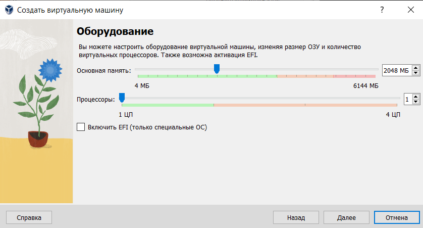

(рис. 3. Размер пямяти и число процессоров)

4. Задайте конфигурацию жёсткого диска — загрузочный,VDI (BirtualBox Disk Image), динамический виртуальный диск. Задайте размер диска — 25 ГБ (или больше).

[figure not shown]

(рис. 4. Виртуальный жесткий диск)

[figure not shown]

(рис. 5. Итог настроек)

5. Добавьте новый привод оптических дисков и выберите образ операционной системы.

[figure not shown]

(рис. 6. Носители)

[figure not shown]

7. Задаем hostname, пароль и полное имя.

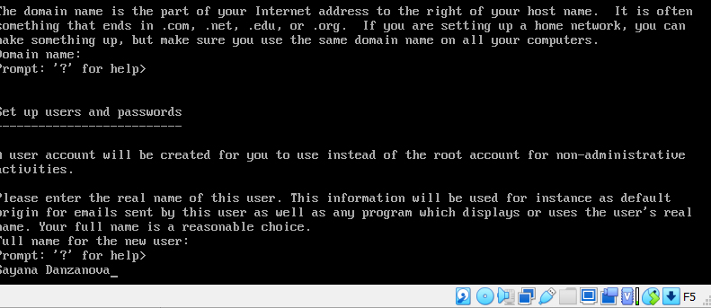

8. Настроим часовой пояс и время

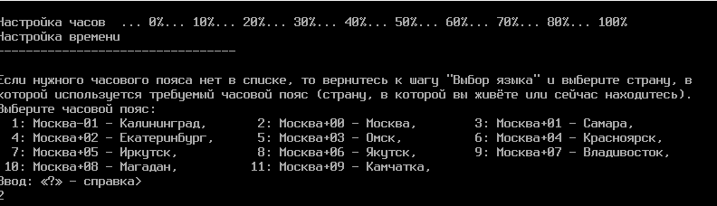

(рис. 9. Настройка часового пояса и времени)

8. Настроим диски

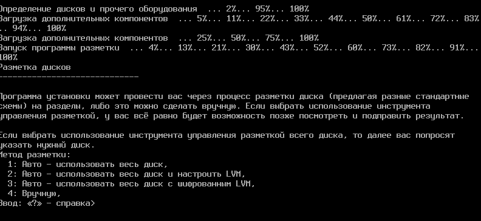

(рис. 10. Настройка дисков)

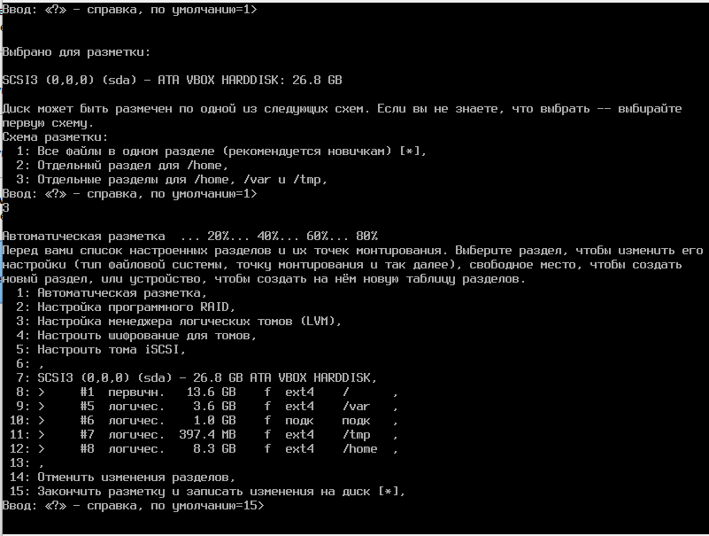

(рис. 11. Настройка дисков)

# Вывод

## Вывод

- Были получены практические навыки настройки рабочего пространства для выполнения индивидуального проекта, приобретены практические навыки установки операционной системы на виртуальную машину.

# Список литературы. Библиография

[1] Сайт Kali Linux: https://www.kali.org/

[2] Документация Kali Linux: https://docs.kali.org/

[3] Kali Linux Forum: https://forums.kali.org/